# Laboratorio 3.1: Clustering

### Pregunta 6

Un experto en pingüinos ha analizado los datos y ha determinado que los pingüinos encontrados corresponden a 3 tipos de especies: Adelie, Gentoo y Chinstrap.

[figure not shown]

```python
df_s = pd.read_csv("https://ortizfuentes.com/datasets/penguins_species.csv", sep=",")
df_s.value_counts()
```

```
species
Adelie       146
Gentoo       119
Chinstrap     68
dtype: int64
```

Compare la clasificación del experto con los resultados con alguno de sus modelos de clustering. ¿Qué puede decir de los clusters generados? ¿Cómo se comportan en comparación al anotado del experto?

Hint: puede ocupar métricas de comparación, visualizaciones o bien usar los métodos [groupby](https://pandas.pydata.org/pandas-docs/stable/reference/api/pandas.DataFrame.groupby.html) y [value_counts](https://pandas.pydata.org/pandas-docs/stable/reference/api/pandas.DataFrame.value_counts.html) de pandas para comparar los datos de las tablas.

```python
from sklearn.metrics.pairwise import euclidean_distances

# Prestado del tutorial

def sim_matrix(features, labels):
    useful_labels = labels >= 0

    # primero ordenamos los datos en base al cluster que pertencen
    indices = np.argsort(labels[useful_labels])
    sorted_features = features[useful_labels][indices]

    # calculamos las distancias entre todos los puntos
    d = euclidean_distances(sorted_features, sorted_features)
    return d

def plot(data, model):
    fig, (ax1, ax2) = plt.subplots(1, 2, figsize=(20,5))

    fig.suptitle(f"{model.__class__.__name__}")

    ax1.scatter(data[:,0], data[:,1], c=model.labels_)

    dist = sim_matrix(data, model.labels_)
    im = ax2.imshow(dist, cmap="jet")
    fig.colorbar(im, ax=ax2)
```

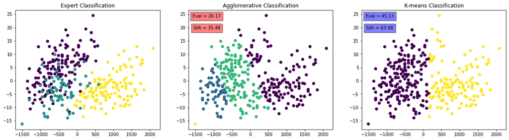

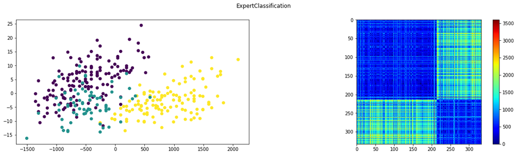

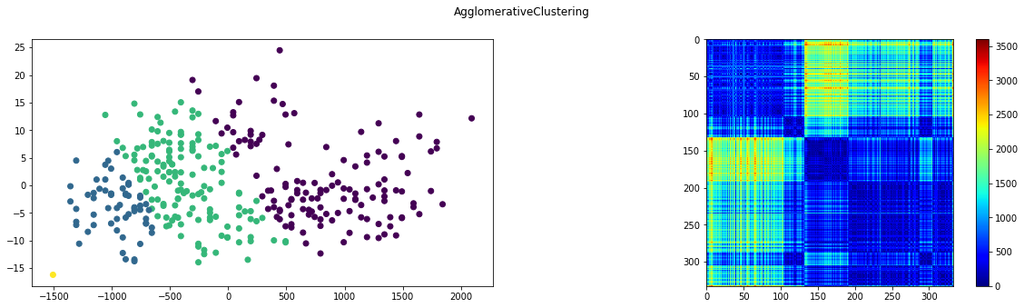

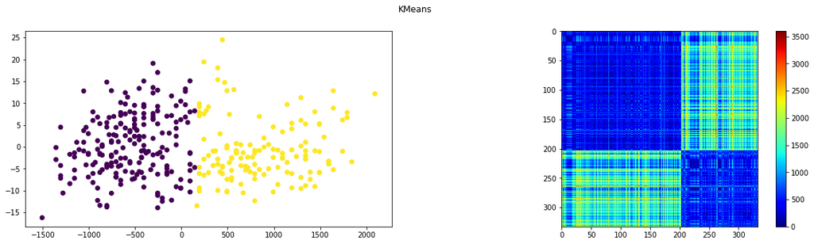

```python
from sklearn.metrics import mutual_info_score, adjusted_mutual_info_score, normalized_mutual_info_score, silhouette_score
df_dm = pd.get_dummies(df_s['species'])
v1    = df_dm['Adelie']
v2    = df_dm['Chinstrap']
v3    = df_dm['Gentoo']
v_label = v1 + 2*v2 + 3*v3
fig, (ax1, ax2, ax3) = plt.subplots(1, 3, figsize=(20,5))
ax1.scatter(new_X[:, 0], new_X[:, 1], c=v_label)
ax1.set_title("Expert Classification")

ax2.scatter(new_X[:, 0], new_X[:, 1], c=complete_dist.labels_)
ax2.set_title("Agglomerative Classification")
ag_ev = round(normalized_mutual_info_score(v_label, complete_dist.labels_)*10000)/100
ag_sl = round(silhouette_score(new_X, complete_dist.labels_)*10000)/100
ax2.text(0.125, 0.95, f"Eval = {ag_ev}", bbox={'facecolor': 'red', 'alpha': 0.5, 'pad': 5}, horizontalalignment='center', verticalalignment='center', transform=ax2.transAxes)
ax2.text(0.125, 0.85, f"Silh = {ag_sl}", bbox={'facecolor': 'red', 'alpha': 0.5, 'pad': 5}, horizontalalignment='center', verticalalignment='center', transform=ax2.transAxes)

ax3.scatter(new_X[:, 0], new_X[:, 1], c=kmeans.labels_)
ax3.set_title("K-means Classification")
km_ev = round(normalized_mutual_info_score(v_label, kmeans.labels_)*10000)/100
km_sl = round(silhouette_score(new_X, kmeans.labels_)*10000)/100
ax3.text(0.125, 0.95, f"Eval = {km_ev}", bbox={'facecolor': 'blue', 'alpha': 0.5, 'pad': 5}, horizontalalignment='center', verticalalignment='center', transform=ax3.transAxes)
ax3.text(0.125, 0.85, f"Silh = {km_sl}", bbox={'facecolor': 'blue', 'alpha': 0.5, 'pad': 5}, horizontalalignment='center', verticalalignment='center', transform=ax3.transAxes)
fig.show()

df_tlabel = pd.DataFrame(v_label)
df_tlabel.labels_ = v_label
df_tlabel.__class__.__name__ = "ExpertClassification"
plot(new_X, df_tlabel)
plot(new_X, complete_dist)
plot(new_X, kmeans)
```

Los cluster generados, muestran ambos claras designaciones de los datos al clasificarlos, no obstante estas divisiones no coinciden con la hecha del experto, y esto bien se podria explicar en si mismo en los datos, los cuales visualizando la clasificacion del experto se puede ver una gran interseccion en dos especies y por otro lado tambien se logra apreciar una muy tenue division con la tercera, no obstante en la matriz de similitud si alcanzamos a divisar, la que la poco determinante, pero mas certera que aglomeracion KMeans logro divisar mucho mejor.

En general creemos que pese a los resultados, hay poco espacio para mejora al menos siguiendo la metodologia realizada en este laboratorio.